# Week 10 Q&A session

# Questions

- previous lectures, homeworks, midterm
- this week quiz
- this week assignment

# Ch.4 Ex.4

*“When the number of features $p$ is large, there tends to be a deterioration in the performance of KNN and other local approaches that perform prediction using only observations that are near the test observation for which a prediction must be made. This phenomenon is known as the curse of dimensionality, and it ties into the fact that non-parametric approaches often perform poorly when $p$ is large. We will now investigate this curse.”*

*“(a) Suppose that we have a set of observations, each with measurements on $p = 1$ feature, $X$. We assume that $X$ is uniformly (evenly) distributed on $[0, 1]$. Associated with each observation is a response value. Suppose that we wish to predict a test observation’s response using only observations that are within 10% of the range of $X$ closest to that test observation. For instance, in order to predict the response for a test observation with $X = 0.6$, we will use observations in the range $[0.55, 0.65]$. On average, what fraction of the available observations will we use to make the prediction?”*

```r
thresh <- 0.1
nobs <- 10000
mean(runif(nobs)<thresh)
```

```
## [1] 0.1051
```

*“(b) Now suppose that we have a set of observations, each with measurements on $p = 2$ features, $X_1$ and $X_2$. We assume that $(X_1,X_2)$ are uniformly distributed on $[0, 1] \times [0, 1]$. We wish to predict a test observation’s response using only observations that are within 10% of the range of $X_1$ and within 10% of the range of $X_2$ closest to that test observation. For instance, in order to predict the response for a test observation with $X_1 = 0.6$ and $X_2 = 0.35$, we will use observations in the range $[0.55, 0.65]$ for $X_1$ and in the range $[0.3, 0.4]$ for $X_2$. On average, what fraction of the available observations will we use to make the prediction?”*

```r
# p=2:
mean(runif(nobs)<thresh&runif(nobs)<thresh)
```

```
## [1] 0.0108
```

```r
# p=3:
mean(runif(nobs)<thresh&runif(nobs)<thresh&runif(nobs)<thresh)
```

```
## [1] 6e-04
```

```r
# p=10:
nvars <- 10
nobs <- 100000
thresh <- 0.5
xTmp <- matrix(runif(nobs*nvars),ncol=nvars)
mean(rowMeans(xTmp<thresh)==1)
```

```
## [1] 0.00096
```

```r
thresh ^ nvars
```

```
## [1] 0.0009765625
```

```r
mean(rowMeans(xTmp>0.1&xTmp<0.9)==1)
```

```
## [1] 0.10862
```

```r
0.8^nvars
```

```
## [1] 0.1073742
```

*“(c) Now suppose that we have a set of observations on $p = 100$ features. Again the observations are uniformly distributed on each feature, and again each feature ranges in value from 0 to 1. We wish to predict a test observation’s response using observations within the 10% of each feature’s range that is closest to that test observation. What fraction of the available observations will we use to make the prediction?”*

```r
0.1^100
```

```
## [1] 1e-100
```

*“(d) Using your answers to parts (a)-(c), argue that a drawback of KNN when $p$ is large is that there are very few training observations”near" any given test observation."*

*“(e) Now suppose that we wish to make a prediction for a test observation by creating a $p$-dimensional hypercube centered around the test observation that contains, on average, 10% of the training observations. For $p = 1, 2,$ and $100$, what is the length of each side of the hypercube? Comment on your answer.”*

```r
for ( nvars in c(1,2,5,10,20,50,100) ) {
  cat("p =",nvars,", x =", 0.1^(1/nvars),fill=TRUE)
}
```

```
## p = 1 , x = 0.1
## p = 2 , x = 0.3162278
## p = 5 , x = 0.6309573
## p = 10 , x = 0.7943282
## p = 20 , x = 0.8912509
## p = 50 , x = 0.9549926
## p = 100 , x = 0.9772372
```

# Ch.4 Ex.10

*“This question should be answered using the `Weekly` data set, which is part of the ISLR package. This data is similar in nature to the `Smarket` data from this chapter’s lab, except that it contains 1,089 weekly returns for 21 years, from the beginning of 1990 to the end of 2010.”*

*“(a) Produce some numerical and graphical summaries of the `Weekly` data. Do there appear to be any patterns?”*

```r
head(Weekly)
```

```
##   Year   Lag1   Lag2   Lag3   Lag4   Lag5    Volume  Today Direction
## 1 1990  0.816  1.572 -3.936 -0.229 -3.484 0.1549760 -0.270      Down
## 2 1990 -0.270  0.816  1.572 -3.936 -0.229 0.1485740 -2.576      Down
## 3 1990 -2.576 -0.270  0.816  1.572 -3.936 0.1598375  3.514        Up
## 4 1990  3.514 -2.576 -0.270  0.816  1.572 0.1616300  0.712        Up
## 5 1990  0.712  3.514 -2.576 -0.270  0.816 0.1537280  1.178        Up
## 6 1990  1.178  0.712  3.514 -2.576 -0.270 0.1544440 -1.372      Down
```

```r
range(Weekly[-nrow(Weekly),"Lag1"]-Weekly[-1,"Lag2"])
```

```
## [1] 0 0
```

```r
range(Weekly[-nrow(Weekly),"Lag4"]-Weekly[-1,"Lag5"])
```

```
## [1] 0 0
```

```r
summary(Weekly)
```

```
##       Year           Lag1               Lag2               Lag3
##  Min.   :1990   Min.   :-18.1950   Min.   :-18.1950   Min.   :-18.1950
##  1st Qu.:1995   1st Qu.: -1.1540   1st Qu.: -1.1540   1st Qu.: -1.1580
##  Median :2000   Median :  0.2410   Median :  0.2410   Median :  0.2410
##  Mean   :2000   Mean   :  0.1506   Mean   :  0.1511   Mean   :  0.1472
##  3rd Qu.:2005   3rd Qu.:  1.4050   3rd Qu.:  1.4090   3rd Qu.:  1.4090
##  Max.   :2010   Max.   : 12.0260   Max.   : 12.0260   Max.   : 12.0260
##       Lag4               Lag5              Volume
##  Min.   :-18.1950   Min.   :-18.1950   Min.   :0.08747
##  1st Qu.: -1.1580   1st Qu.: -1.1660   1st Qu.:0.33202
##  Median :  0.2380   Median :  0.2340   Median :1.00268
##  Mean   :  0.1458   Mean   :  0.1399   Mean   :1.57462
##  3rd Qu.:  1.4090   3rd Qu.:  1.4050   3rd Qu.:2.05373
##  Max.   : 12.0260   Max.   : 12.0260   Max.   :9.32821
##      Today          Direction
##  Min.   :-18.1950   Down:484
##  1st Qu.: -1.1540   Up  :605
##  Median :  0.2410
##  Mean   :  0.1499
##  3rd Qu.:  1.4050
##  Max.   : 12.0260
```

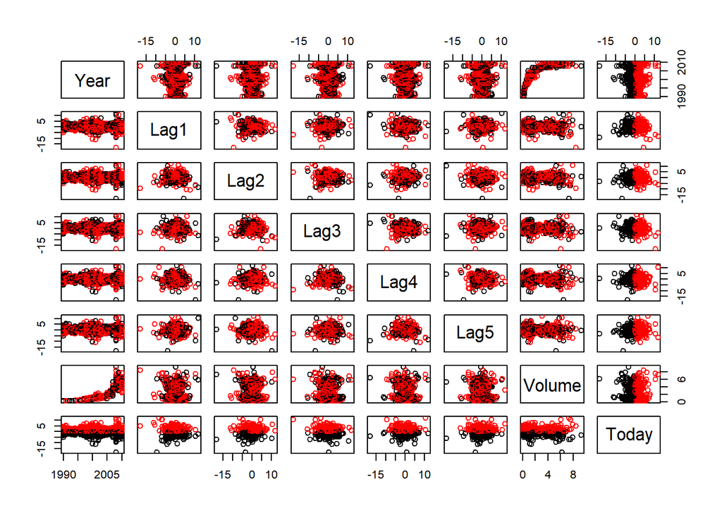

```r
pairs(Weekly[,colnames(Weekly)!="Direction"],col=Weekly[,"Direction"])
```

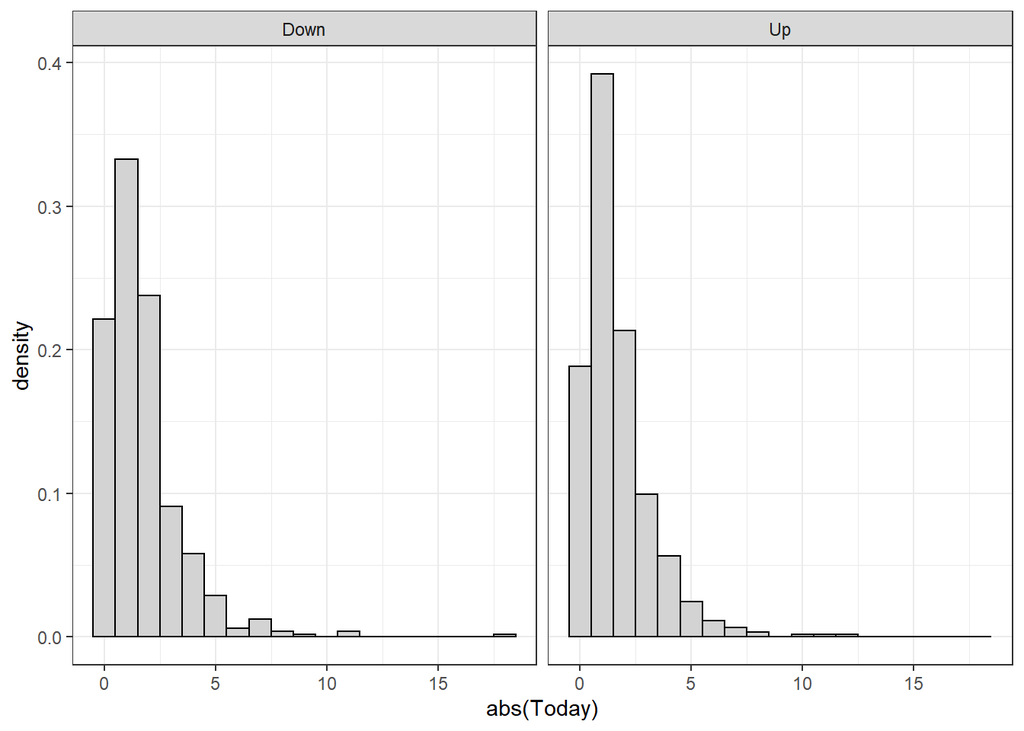

```r
ggplot(Weekly,aes(x=abs(Today)))+geom_histogram(aes(y=..density..),binwidth = 1,fill="lightgray",colour="black")+facet_wrap(~Direction)+theme_bw()
```

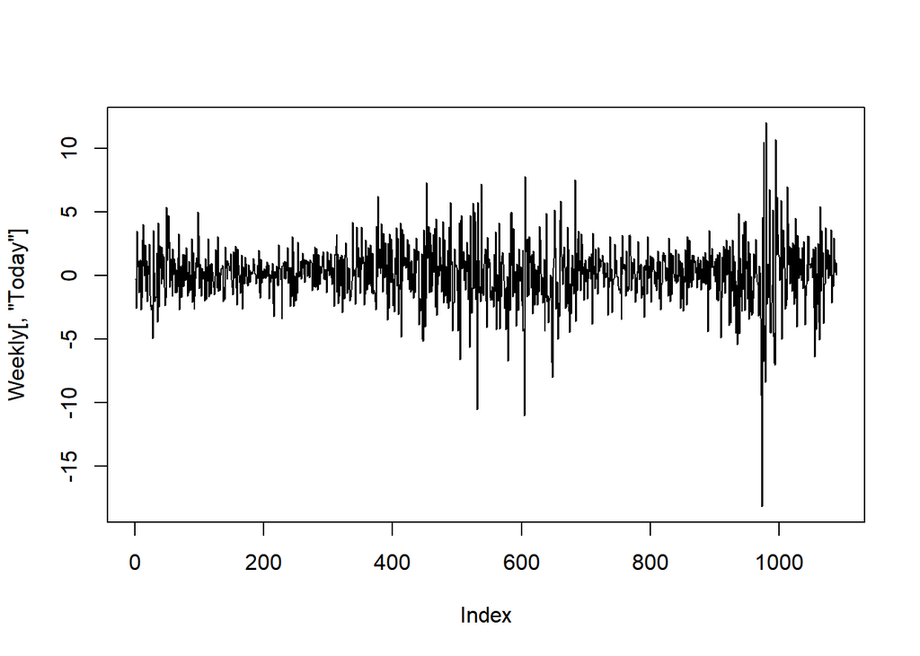

```r
plot(Weekly[,"Today"],type="l")
```

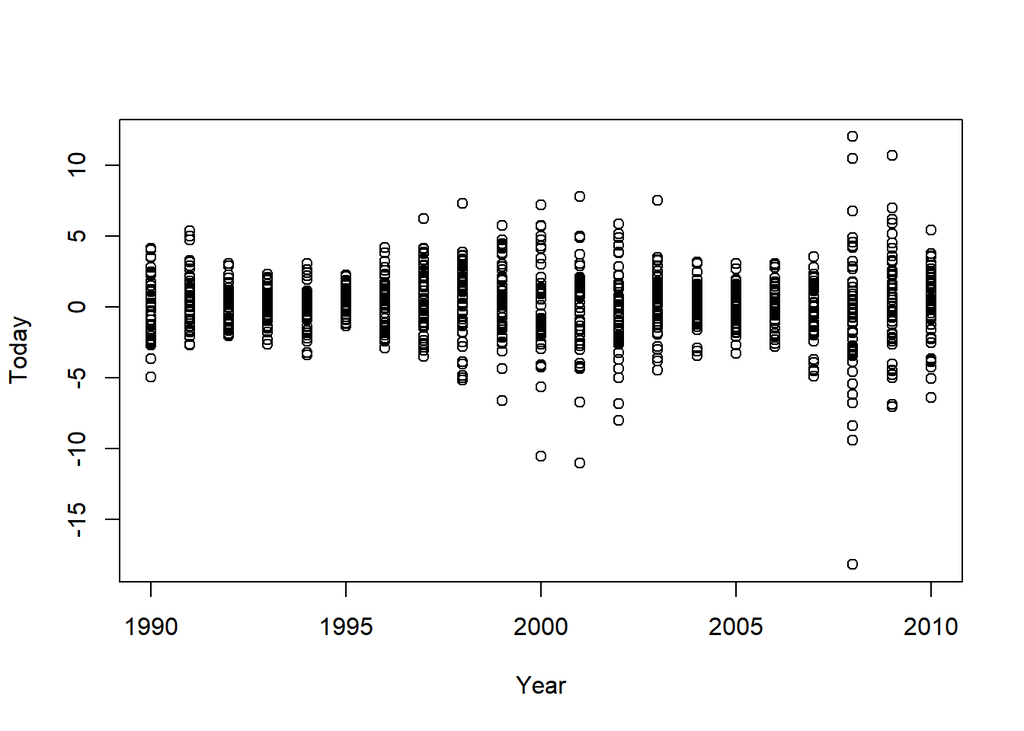

```r
plot(Weekly[,c("Year","Today")])
```

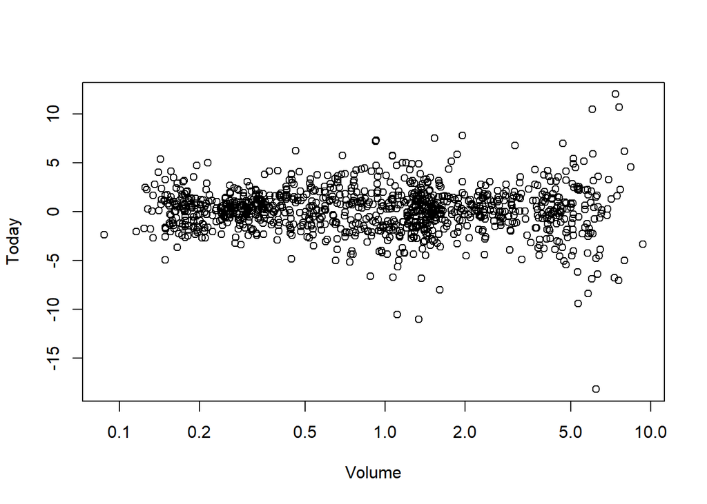

```r
plot(Weekly[,c("Volume","Today")],log="x")
```

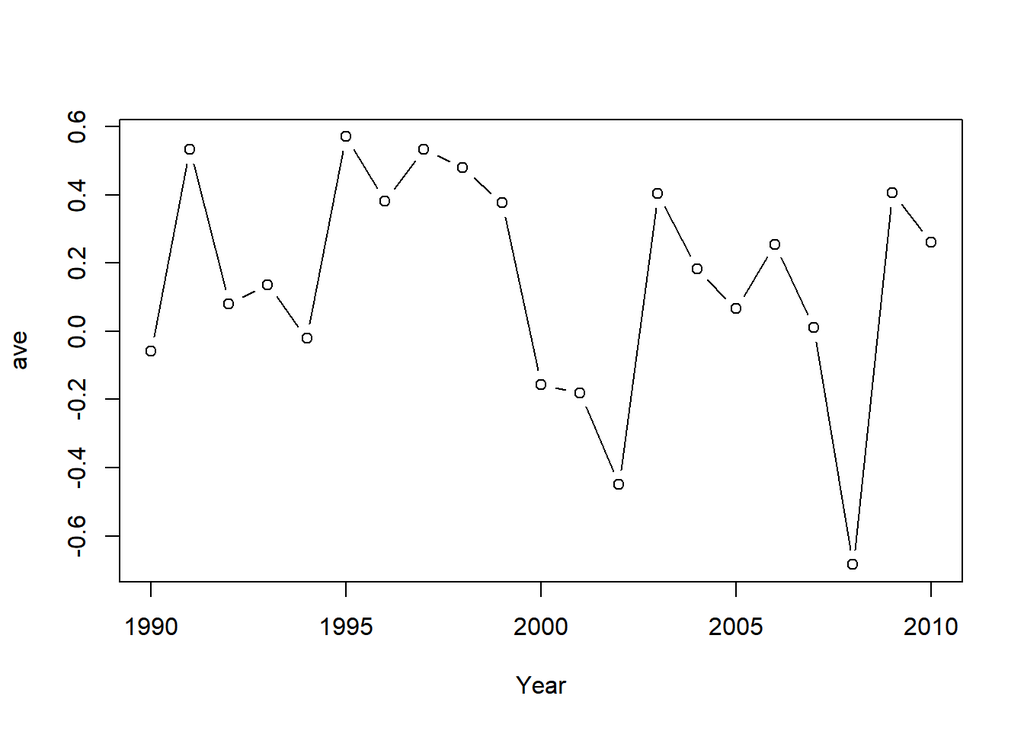

```r
plot(plyr::ddply(Weekly,~Year,plyr::summarize,ave=mean(Today)),type="b")
```

*“(b) Use the full data set to perform a logistic regression with `Direction` as the response and the five lag variables plus `Volume` as predictors. Use the summary function to print the results. Do any of the predictors appear to be statistically significant? If so, which ones?”*

```r
glmFit <- glm(Direction~Lag1+Lag2+Lag3+Lag4+Lag5+Volume,data=Weekly,family=binomial)
summary(glmFit)
```

```
##
## Call:
## glm(formula = Direction ~ Lag1 + Lag2 + Lag3 + Lag4 + Lag5 +
##     Volume, family = binomial, data = Weekly)
##
## Deviance Residuals:
##     Min       1Q   Median       3Q      Max
## -1.6949  -1.2565   0.9913   1.0849   1.4579
##
## Coefficients:
##             Estimate Std. Error z value Pr(>|z|)
## (Intercept)  0.26686    0.08593   3.106   0.0019 **
## Lag1        -0.04127    0.02641  -1.563   0.1181
## Lag2         0.05844    0.02686   2.175   0.0296 *
## Lag3        -0.01606    0.02666  -0.602   0.5469
## Lag4        -0.02779    0.02646  -1.050   0.2937
## Lag5        -0.01447    0.02638  -0.549   0.5833
## Volume      -0.02274    0.03690  -0.616   0.5377
## ---
## Signif. codes:  0 '***' 0.001 '**' 0.01 '*' 0.05 '.' 0.1 ' ' 1
##
## (Dispersion parameter for binomial family taken to be 1)
##
##     Null deviance: 1496.2  on 1088  degrees of freedom
## Residual deviance: 1486.4  on 1082  degrees of freedom
## AIC: 1500.4
##
## Number of Fisher Scoring iterations: 4
```

```r
# p<0.05 in randomized data:
pTmp <- NULL
for ( iSim in 1:1000 ) {
  wTmp <- Weekly
  wTmp$Direction <- sample(wTmp$Direction)
  glmSim <- glm(Direction~Lag1+Lag2+Lag3+Lag4+Lag5+Volume,data=wTmp,family=binomial)
  pTmp <- rbind(pTmp,summary(glmSim)$coefficients[-1,"Pr(>|z|)"])
}
dim(pTmp)
```

```
## [1] 1000    6
```

```r
sum(pTmp<0.05)/prod(dim(pTmp))
```

```
## [1] 0.05033333
```

```r
sum(apply(pTmp,1,min)<0.05)/nrow(pTmp)
```

```
## [1] 0.265
```

```r
sum(pTmp<0.03)/prod(dim(pTmp))
```

```
## [1] 0.0305
```

```r
sum(apply(pTmp,1,min)<0.03)/nrow(pTmp)
```

```
## [1] 0.169
```

### Decision boundaries for unbalanced datasets

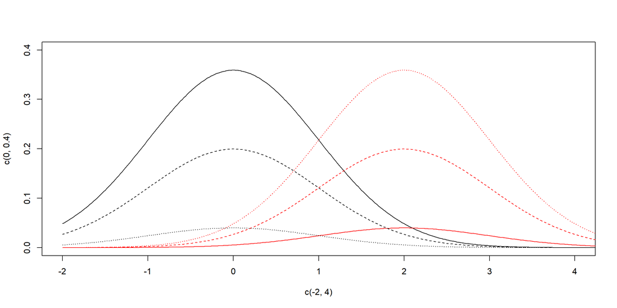

```r
nSmpl <- 10000
dMu <- 2
plot(c(-2,4),c(0,0.4),type="n")
for ( i in 1:3 ) {
  frac1 <- c(0.1,0.5,0.9)[i]
  points((-100:400)/50,(1-frac1)*dnorm((-100:400)/50),col=1,type="l",lty=i)
  points((-100:400)/50,frac1*dnorm((-100:400)/50,mean=dMu),col=2,type="l",lty=i)
}
```

```r
old.par<-par(mfrow=c(1,3))
for ( iWght in 1:2 ) {
  plot(c(-2,4),c(0,1),type="n",main=c("Unweighted","Weighted")[iWght],xlab="X",ylab="Pr(1|X)")
  abline(v=dMu/2,lty=2)
  abline(h=(1:9)/10,lty=2)
  for ( frac1 in (1:9)/10 ) {
    x <- rnorm(nSmpl)
    y <- rep(0,nSmpl)
    id1 <- 1:floor(frac1*nSmpl)
    x[id1] <- x[id1] + dMu
    y[id1] <- 1
    wghts <- NULL
    if ( iWght == 2 ) {
      wghts <- c(mean(y),1-mean(y))[y+1]
    }
    glmRes <- glm(y~x,family=binomial,weights=wghts)
    cat(iWght,ifelse(is.null(wghts),sum(y),sum(wghts*y)),ifelse(is.null(wghts),sum(predict(glmRes,type="response")),sum(wghts*predict(glmRes,type="response"))),coef(glmRes),mean(y==(predict(glmRes)>0)),mean(y==(predict(glmRes,type="response")>mean(y))),fill=TRUE)
    points((-10:40)/5,predict(glmRes,newdata=data.frame(x=(-10:40)/5),type="response"),type="l",col=frac1*10)
    abline(v=-coef(glmRes)[1]/coef(glmRes)[2],lty=2,col=frac1*10)
  }
}
```

```
## 1 1000 1000 -4.059243 1.919978 0.9254 0.8333
## 1 2000 2000 -3.317754 1.940478 0.8847 0.8354
## 1 3000 3000 -2.814068 1.965373 0.8559 0.8385
## 1 4000 4000 -2.361483 1.968314 0.8416 0.8388
## 1 5000 5000 -1.961591 1.970984 0.8391 0.8391
## 1 6000 6000 -1.706783 2.0599 0.8515 0.8497
## 1 7000 7000 -1.16922 2.003463 0.8642 0.842
## 1 8000 8000 -0.6565885 2.051886 0.8913 0.8412
## 1 9000 9000 0.2496624 1.987875 0.9303 0.8437
```

```
## 2 900 900 -1.972638 1.93808 0.8431 0.5044
## 2 1600 1600 -2.027674 2.022179 0.8381 0.6856
## 2 2100 2100 -2.011394 2.041802 0.8434 0.7885
## 2 2400 2400 -1.958864 1.960271 0.8342 0.8233
## 2 2500 2500 -2.024203 2.018137 0.8426 0.8426
## 2 2400 2400 -2.005639 1.955852 0.8362 0.8222
## 2 2100 2100 -2.049424 2.016844 0.8423 0.78
## 2 1600 1600 -2.044549 2.040768 0.8428 0.6896
## 2 900 900 -1.9479 1.964541 0.8382 0.5032
```

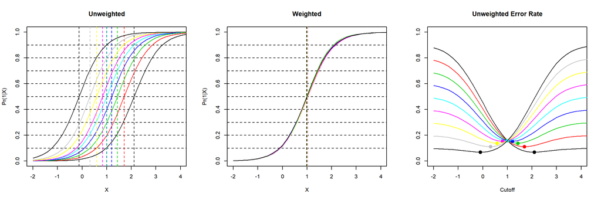

```r
plot(c(-2,4),c(0,1),type="n",main="Unweighted Error Rate",xlab="Cutoff",ylab="")
for ( frac1 in (1:9)/10 ) {
  points((-10:40)/5,(1-frac1)*pnorm((-10:40)/5,lower.tail=FALSE)+frac1*pnorm((-10:40)/5,mean=dMu,lower.tail=TRUE),type="l",col=frac1*10)
  optRes <- optimize(function(x)(1-frac1)*pnorm(x,lower.tail=FALSE)+frac1*pnorm(x,mean=dMu,lower.tail=TRUE),c(-2,4))
  points(optRes$minimum,optRes$objective,col=frac1*10,pch=20,cex=2)
}
```

```r
par(old.par)
```

On unbalanced datasets in the absence of weights decision boundary defined by `predict(...,type="response")==0.5` (or, equivalently, `predict(...,type="link")==0`) minimizes error subject to the proportions of the classes in the training data. Proper use of weights allows to minimize it for balanced sample (population). Also, *expected* number of class labels equals to the *observed*.

*“(c) Compute the confusion matrix and overall fraction of correct predictions. Explain what the confusion matrix is telling you about the types of mistakes made by logistic regression.”*

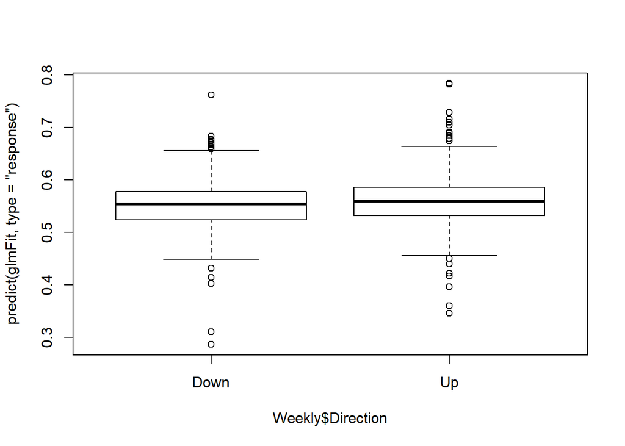

```r
boxplot(predict(glmFit,type="response")~Weekly$Direction)
```

```r
quantile(predict(glmFit,type="response"))
```

```
##        0%       25%       50%       75%      100%
## 0.2864474 0.5276638 0.5573610 0.5819323 0.7837046
```

```r
table(Weekly$Direction,c("Down","Up")[1+(predict(glmFit)>0.0)])
```

```
##
##        Down  Up
##   Down   54 430
##   Up     48 557
```

```r
tblTmp <- table(Weekly$Direction,c("Down","Up")[1+(predict(glmFit,type="response")>0.5)])
tblTmp
```

```
##
##        Down  Up
##   Down   54 430
##   Up     48 557
```

```r
# sensitivity for predicting "Up":
tblTmp[2,2] / sum(tblTmp[2,])
```

```
## [1] 0.9206612
```

```r
# specificity for predicting "Up":
tblTmp[1,1] / sum(tblTmp[1,])
```

```
## [1] 0.1115702
```

```r
rocDatTmp <- NULL
for ( qTmp in quantile(predict(glmFit,type="response"),(0:10)/10) ) {
  tblTmp <- table(Weekly$Direction,factor(c("Down","Up")[1+(predict(glmFit,type="response")>=qTmp)],c("Down","Up")))
  cat(qTmp,tblTmp[2,2] / sum(tblTmp[2,]),tblTmp[1,1] / sum(tblTmp[1,]),fill=TRUE)
  rocDatTmp <- rbind(rocDatTmp,c(1-tblTmp[1,1] / sum(tblTmp[1,]),tblTmp[2,2] / sum(tblTmp[2,])))
}
```

```
## 0.2864474 1 0
## 0.5016955 0.9157025 0.1198347
## 0.5217532 0.8198347 0.2252066
## 0.5357692 0.7338843 0.3429752
## 0.5462799 0.6363636 0.446281
## 0.557361 0.5289256 0.535124
## 0.5663792 0.4330579 0.6404959
## 0.5767059 0.3355372 0.7438017
## 0.5876498 0.2181818 0.822314
## 0.605294 0.1190083 0.9235537
## 0.7837046 0.001652893 1
```

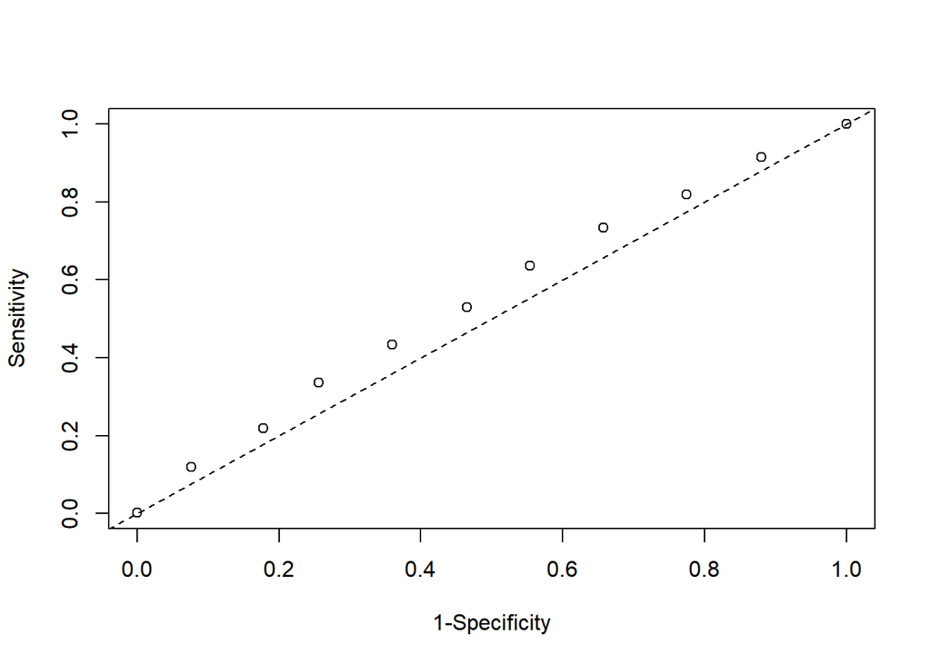

```r
plot(rocDatTmp,ylab="Sensitivity",xlab="1-Specificity")
abline(0,1,lty=2)
```

```r
assess.prediction=function(truth,predicted) {
   # same length:
   if ( length(truth) != length(predicted) ) {
     stop("truth and predicted must be same length!")
   }
   # check for missing values (we are going to
   # compute metrics on non-missing values only)
   bKeep = ! is.na(truth)  & ! is.na(predicted)
   predicted = predicted[ bKeep ]
   truth = truth[ bKeep ]
   # only 0 and 1:
   if ( sum(truth%in%c(0,1))+sum(predicted%in%c(0,1))!=2*length(truth) ) {
     stop("only zeroes and ones are allowed!")
   }
   cat("Total cases that are not NA: ",
         length(truth),"\n",sep="")
   # overall accuracy of the test: how many cases
   # (both positive and
   # negative) we got right:
   cat("Correct predictions (accuracy): ",
     sum(truth==predicted),
     "(",signif(sum(truth==predicted)*100/
     length(truth),3),"%)\n",sep="")
   # how predictions align against known
   # training/testing outcomes:
   # TP/FP= true/false positives,
   # TN/FN=true/false negatives
   TP = sum(truth==1 & predicted==1)
   TN = sum(truth==0 & predicted==0)
   FP = sum(truth==0 & predicted==1)
   FN = sum(truth==1 & predicted==0)
   P = TP+FN  # total number of
         # positives in the truth data
   N = FP+TN  # total number of
              # negatives
   cat("TP, TN, FP, FN, P, N:",TP, TN, FP, FN, P, N, fill=TRUE)
   cat("TPR (sensitivity)=TP/P: ",
       signif(100*TP/P,3),"%\n",sep="")
   cat("TNR (specificity)=TN/N: ",
       signif(100*TN/N,3),"%\n",sep="")
   cat("PPV (precision)=TP/(TP+FP): ",
       signif(100*TP/(TP+FP),3),"%\n",sep="")
   cat("FDR (false discovery)=1-PPV: ",
       signif(100*FP/(TP+FP),3),"%\n",sep="")
   cat("FPR =FP/N=1-TNR: ",
      signif(100*FP/N,3),"%\n",sep="")
}
```

```r
assess.prediction(as.numeric(Weekly$Direction)-1,as.numeric(predict(glmFit,type="response")>0.5))
```

```
## Total cases that are not NA: 1089
## Correct predictions (accuracy): 611(56.1%)
## TP, TN, FP, FN, P, N: 557 54 430 48 605 484
## TPR (sensitivity)=TP/P: 92.1%
## TNR (specificity)=TN/N: 11.2%
## PPV (precision)=TP/(TP+FP): 56.4%
## FDR (false discovery)=1-PPV: 43.6%
## FPR =FP/N=1-TNR: 88.8%
```

```r
# majority vote:
table(Weekly$Direction) / nrow(Weekly)
```

```
##
##      Down        Up
## 0.4444444 0.5555556
```

*“(d) Now fit the logistic regression model using a training data period from 1990 to 2008, with `Lag2` as the only predictor. Compute the confusion matrix and the overall fraction of correct predictions for the held out data (that is, the data from 2009 and 2010).”*

```r
# train on year 2008 or before (why only Lag2??):
glmFitLeq2008 <- glm(Direction~Lag2,data=Weekly[Weekly$Year<=2008,],family=binomial)
summary(glmFitLeq2008)
```

```
##
## Call:
## glm(formula = Direction ~ Lag2, family = binomial, data = Weekly[Weekly$Year <=
##     2008, ])
##
## Deviance Residuals:
##    Min      1Q  Median      3Q     Max
## -1.536  -1.264   1.021   1.091   1.368
##
## Coefficients:
##             Estimate Std. Error z value Pr(>|z|)
## (Intercept)  0.20326    0.06428   3.162  0.00157 **
## Lag2         0.05810    0.02870   2.024  0.04298 *
## ---
## Signif. codes:  0 '***' 0.001 '**' 0.01 '*' 0.05 '.' 0.1 ' ' 1
##
## (Dispersion parameter for binomial family taken to be 1)
##
##     Null deviance: 1354.7  on 984  degrees of freedom
## Residual deviance: 1350.5  on 983  degrees of freedom
## AIC: 1354.5
##
## Number of Fisher Scoring iterations: 4
```

```r
tblTmp <- table(Weekly[Weekly$Year>2008,"Direction"],c("Down","Up")[1+(predict(glmFitLeq2008,newdata=Weekly[Weekly$Year>2008,],type="response")>0.5)])
tblTmp
```

```
##
##        Down Up
##   Down    9 34
##   Up      5 56
```

```r
tblTmp[2,2] / sum(tblTmp[2,])
```

```
## [1] 0.9180328
```

```r
tblTmp[1,1] / sum(tblTmp[1,])
```

```
## [1] 0.2093023
```

```r
assess.prediction(as.numeric(Weekly[Weekly$Year>2008,"Direction"])-1,as.numeric(predict(glmFitLeq2008,newdata=Weekly[Weekly$Year>2008,],type="response")>median(predict(glmFitLeq2008,type="response"))))
```

```
## Total cases that are not NA: 104
## Correct predictions (accuracy): 54(51.9%)
## TP, TN, FP, FN, P, N: 33 21 22 28 61 43
## TPR (sensitivity)=TP/P: 54.1%
## TNR (specificity)=TN/N: 48.8%
## PPV (precision)=TP/(TP+FP): 60%
## FDR (false discovery)=1-PPV: 40%
## FPR =FP/N=1-TNR: 51.2%
```

*“(e) Repeat (d) using LDA.”*

```r
ldaLeq2008 <- lda(Direction~Lag2,data=Weekly[Weekly$Year<=2008,])
ldaLeq2008 <- lda(Direction~Lag1+Lag2+Lag3+Lag4+Lag5+Volume,data=Weekly[Weekly$Year<=2008,])
ldaLeq2008
```

```
## Call:
## lda(Direction ~ Lag1 + Lag2 + Lag3 + Lag4 + Lag5 + Volume, data = Weekly[Weekly$Year <=
##     2008, ])
##
## Prior probabilities of groups:
##      Down        Up
## 0.4477157 0.5522843
##
## Group means:
##              Lag1        Lag2       Lag3       Lag4       Lag5   Volume
## Down  0.289444444 -0.03568254 0.17080045 0.15925624 0.21409297 1.266966
## Up   -0.009213235  0.26036581 0.08404044 0.09220956 0.04548897 1.156529
##
## Coefficients of linear discriminants:
##                LD1
## Lag1   -0.27269007
## Lag2    0.19316443
## Lag3   -0.06828419
## Lag4   -0.13646358
## Lag5   -0.16316423
## Volume -0.39859766
```

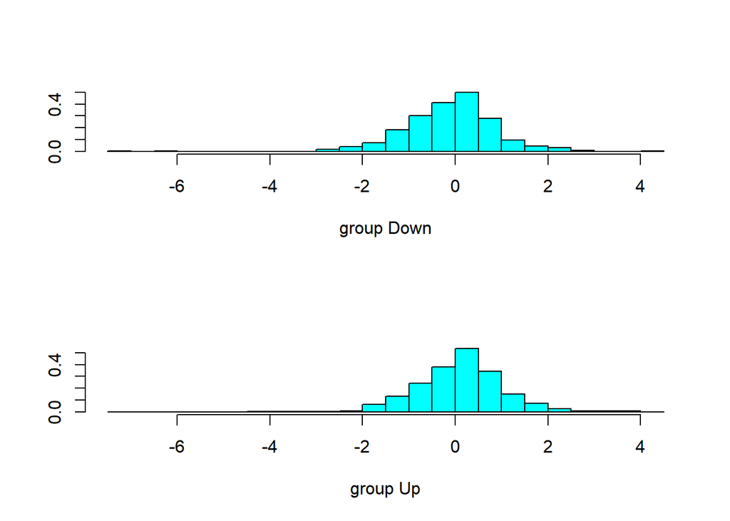

```r
plot(ldaLeq2008)
```

```r
tblTmp <- table(Weekly[Weekly$Year>2008,"Direction"],predict(ldaLeq2008,newdata=Weekly[Weekly$Year>2008,])$class)
tblTmp
```

```
##
##        Down Up
##   Down   31 12
##   Up     44 17
```

```r
tblTmp[2,2] / sum(tblTmp[2,])
```

```
## [1] 0.2786885
```

```r
tblTmp[1,1] / sum(tblTmp[1,])
```

```
## [1] 0.7209302
```

```r
table(Weekly[Weekly$Year>2008,"Direction"],c("Down","Up")[1+(predict(glmFitLeq2008,newdata=Weekly[Weekly$Year>2008,],type="response")>quantile(predict(glmFitLeq2008,type="response"),0.85))])
```

```
##
##        Down Up
##   Down   31 12
##   Up     42 19
```

*“(f) Repeat (d) using QDA.”*

```r
qdaLeq2008 <- qda(Direction~Lag2,data=Weekly[Weekly$Year<=2008,])
qdaLeq2008
```

```
## Call:
## qda(Direction ~ Lag2, data = Weekly[Weekly$Year <= 2008, ])
##
## Prior probabilities of groups:
##      Down        Up
## 0.4477157 0.5522843
##
## Group means:
##             Lag2
## Down -0.03568254
## Up    0.26036581
```

```r
#plot(qdaLeq2008)
tblTmp <- table(Weekly[Weekly$Year>2008,"Direction"],predict(qdaLeq2008,newdata=Weekly[Weekly$Year>2008,])$class)
tblTmp
```

```
##
##        Down Up
##   Down    0 43
##   Up      0 61
```

```r
tblTmp[2,2] / sum(tblTmp[2,])
```

```
## [1] 1
```

```r
tblTmp[1,1] / sum(tblTmp[1,])
```

```
## [1] 0
```

*“(g) Repeat (d) using KNN with $K = 1$.”*

```r
##?knn
knnLeq2008PredGt2008 <- knn(as.matrix(Weekly[Weekly$Year<=2008,"Lag2"]),as.matrix(Weekly[Weekly$Year>2008,"Lag2"]),Weekly[Weekly$Year<=2008,"Direction"],k=1)
tblTmp <- table(Weekly[Weekly$Year>2008,"Direction"],knnLeq2008PredGt2008)
tblTmp
```

```
##       knnLeq2008PredGt2008
##        Down Up
##   Down   21 22
##   Up     30 31
```

```r
tblTmp[2,2] / sum(tblTmp[2,])
```

```
## [1] 0.5081967
```

```r
tblTmp[1,1] / sum(tblTmp[1,])
```

```
## [1] 0.4883721
```

```r
# KNN on all useable attributes:
WeeklyScaled <- Weekly
WeeklyScaled[,c("Volume",paste0("Lag",1:5))] <- scale(WeeklyScaled[,c("Volume",paste0("Lag",1:5))])
knnLeq2008fullPredGt2008 <- knn(as.matrix(Weekly[Weekly$Year<=2008,c("Volume",paste0("Lag",1:5))]),as.matrix(Weekly[Weekly$Year>2008,c("Volume",paste0("Lag",1:5))]),Weekly[Weekly$Year<=2008,"Direction"],k=1)
table(Weekly[Weekly$Year>2008,"Direction"],knnLeq2008fullPredGt2008)
```

```
##       knnLeq2008fullPredGt2008
##        Down Up
##   Down   21 22
##   Up     32 29
```

```r
knn5Leq2008fullPredGt2008 <- knn(as.matrix(Weekly[Weekly$Year<=2008,c("Volume",paste0("Lag",1:5))]),as.matrix(Weekly[Weekly$Year>2008,c("Volume",paste0("Lag",1:5))]),Weekly[Weekly$Year<=2008,"Direction"],k=5)
table(Weekly[Weekly$Year>2008,"Direction"],knn5Leq2008fullPredGt2008)
```

```
##       knn5Leq2008fullPredGt2008
##        Down Up
##   Down   19 24
##   Up     28 33
```

```r
knn15Leq2008fullPredGt2008 <- knn(as.matrix(Weekly[Weekly$Year<=2008,c("Volume",paste0("Lag",1:5))]),as.matrix(Weekly[Weekly$Year>2008,c("Volume",paste0("Lag",1:5))]),Weekly[Weekly$Year<=2008,"Direction"],k=15)
table(Weekly[Weekly$Year>2008,"Direction"],knn15Leq2008fullPredGt2008)
```

```
##       knn15Leq2008fullPredGt2008
##        Down Up
##   Down   20 23
##   Up     23 38
```

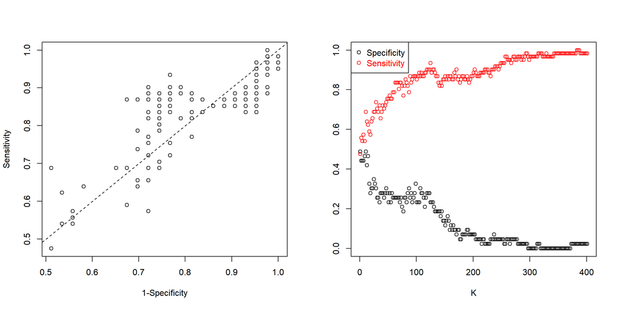

```r
rocDatTmp <- NULL
for ( kTmp in 0:200 ) {
  knnTmp <- knn(as.matrix(Weekly[Weekly$Year<=2008,c("Volume",paste0("Lag",1:5))]),as.matrix(Weekly[Weekly$Year>2008,c("Volume",paste0("Lag",1:5))]),Weekly[Weekly$Year<=2008,"Direction"],k=2*kTmp+1)
  tblTmp <- table(Weekly[Weekly$Year>2008,"Direction"],knnTmp)
  rocDatTmp <- rbind(rocDatTmp,c(2*kTmp+1,1-tblTmp[1,1] / sum(tblTmp[1,]),tblTmp[2,2] / sum(tblTmp[2,])))
}
old.par <- par(mfrow=c(1,2))
plot(rocDatTmp[,-1],xlab="1-Specificity",ylab="Sensitivity")
abline(0,1,lty=2)
plot(rocDatTmp[,1],1-rocDatTmp[,2],xlab="K",ylab="",ylim=c(0,1))
points(rocDatTmp[,1],rocDatTmp[,3],col=2)
legend("topleft",c("Specificity","Sensitivity"),col=1:2,pch=1,text.col=1:2)
```

```r
par(old.par)
```

*“(h) Which of these methods appears to provide the best results on this data?”*

```r
for ( iTry in 1:10 ) {
  trainIdx <- sample(nrow(Weekly),nrow(Weekly),replace=TRUE)
  wTrain <- Weekly[trainIdx,]
  wTest <- Weekly[-trainIdx,]
  glmTry <- glm(Direction~Lag1+Lag2+Lag3+Lag4+Lag5+Volume,data=wTrain,family=binomial)
  ldaTry <- lda(Direction~Lag2+Lag2+Lag3+Lag4+Lag5+Volume,data=wTrain)
  qdaTry <- qda(Direction~Lag2+Lag2+Lag3+Lag4+Lag5+Volume,data=wTrain)
  glmTestRes <- as.numeric(predict(glmTry,newdata=wTest,type="response")>0.5)
  ldaTestRes <- predict(ldaTry,newdata=wTest)$class
  qdaTestRes <- predict(qdaTry,newdata=wTest)$class
  tblTstglm <- table(wTest[,"Direction"],glmTestRes)
  tblTstLDA <- table(wTest[,"Direction"],ldaTestRes)
  tblTstQDA <- table(wTest[,"Direction"],qdaTestRes)
  cat(sum(diag(tblTstglm))/sum(tblTstglm),sum(diag(tblTstLDA))/sum(tblTstLDA),sum(diag(tblTstQDA))/sum(tblTstQDA),fill=TRUE)
}
```

```
## 0.5470297 0.5519802 0.5668317
## 0.5384615 0.5235732 0.5012407
## 0.5695876 0.556701 0.5103093
## 0.5655527 0.5758355 0.5604113
## 0.5328283 0.530303 0.510101
## 0.5113924 0.5088608 0.4962025
## 0.5512195 0.5536585 0.4926829
## 0.5465394 0.5727924 0.4868735
## 0.5148515 0.5049505 0.480198
## 0.5263158 0.5513784 0.556391
```

*“(i) Experiment with different combinations of predictors, including possible transformations and interactions, for each of the methods. Report the variables, method, and associated confusion matrix that appears to provide the best results on the held out data. Note that you should also experiment with values for K in the KNN classifier.”*

```r
glmFullLeq2008 <- glm(Direction~Lag1*Lag2*Lag3*Lag4*Lag5*Volume,data=Weekly[Weekly$Year<=2008,],family=binomial)
summary(glmFullLeq2008)
```

```
##
## Call:
## glm(formula = Direction ~ Lag1 * Lag2 * Lag3 * Lag4 * Lag5 *
##     Volume, family = binomial, data = Weekly[Weekly$Year <= 2008,
##     ])
##
## Deviance Residuals:
##     Min       1Q   Median       3Q      Max
## -2.0332  -1.2303   0.8259   1.0614   1.6013
##
## Coefficients:
##                                   Estimate Std. Error z value Pr(>|z|)
## (Intercept)                      0.2964492  0.1030234   2.877  0.00401 **
## Lag1                            -0.0337966  0.0565207  -0.598  0.54987
## Lag2                             0.0423933  0.0581492   0.729  0.46598
## Lag3                            -0.0109297  0.0566198  -0.193  0.84693
## Lag4                            -0.0530895  0.0578269  -0.918  0.35858
## Lag5                            -0.0949614  0.0578646  -1.641  0.10078
## Volume                          -0.0622140  0.0692401  -0.899  0.36891
## Lag1:Lag2                       -0.0400998  0.0290642  -1.380  0.16768
## Lag1:Lag3                       -0.0370744  0.0299252  -1.239  0.21538
## Lag2:Lag3                       -0.0005412  0.0288835  -0.019  0.98505
## Lag1:Lag4                       -0.0060507  0.0270091  -0.224  0.82274
## Lag2:Lag4                       -0.0211558  0.0306113  -0.691  0.48950
## Lag3:Lag4                        0.0341596  0.0270225   1.264  0.20619
## Lag1:Lag5                       -0.0194132  0.0280856  -0.691  0.48943
## Lag2:Lag5                       -0.0059219  0.0276866  -0.214  0.83063
## Lag3:Lag5                        0.0100649  0.0302032   0.333  0.73895
## Lag4:Lag5                       -0.0432133  0.0261821  -1.650  0.09884 .
## Lag1:Volume                     -0.0379147  0.0399861  -0.948  0.34303
## Lag2:Volume                      0.0252687  0.0409900   0.616  0.53759
## Lag3:Volume                      0.0093438  0.0375597   0.249  0.80354
## Lag4:Volume                      0.0129476  0.0391839   0.330  0.74107
## Lag5:Volume                      0.0471303  0.0384294   1.226  0.22004
## Lag1:Lag2:Lag3                   0.0089432  0.0148934   0.600  0.54819
## Lag1:Lag2:Lag4                  -0.0237403  0.0122584  -1.937  0.05279 .
## Lag1:Lag3:Lag4                  -0.0248023  0.0145826  -1.701  0.08898 .
## Lag2:Lag3:Lag4                  -0.0090151  0.0141983  -0.635  0.52547
## Lag1:Lag2:Lag5                  -0.0121957  0.0126997  -0.960  0.33690
## Lag1:Lag3:Lag5                  -0.0235403  0.0133936  -1.758  0.07882 .
```

[output cut: 31 more lines]

```
## Lag1:Lag2:Lag3:Lag5:Volume      -0.0006154  0.0058108  -0.106  0.91565
## Lag1:Lag2:Lag4:Lag5:Volume       0.0107664  0.0058867   1.829  0.06741 .
## Lag1:Lag3:Lag4:Lag5:Volume       0.0072033  0.0061079   1.179  0.23826
## Lag2:Lag3:Lag4:Lag5:Volume      -0.0101444  0.0066374  -1.528  0.12642
## Lag1:Lag2:Lag3:Lag4:Lag5:Volume  0.0033596  0.0019900   1.688  0.09137 .
## ---
## Signif. codes:  0 '***' 0.001 '**' 0.01 '*' 0.05 '.' 0.1 ' ' 1
##
## (Dispersion parameter for binomial family taken to be 1)
##
##     Null deviance: 1354.7  on 984  degrees of freedom
## Residual deviance: 1274.3  on 921  degrees of freedom
## AIC: 1402.3
##
## Number of Fisher Scoring iterations: 12
```

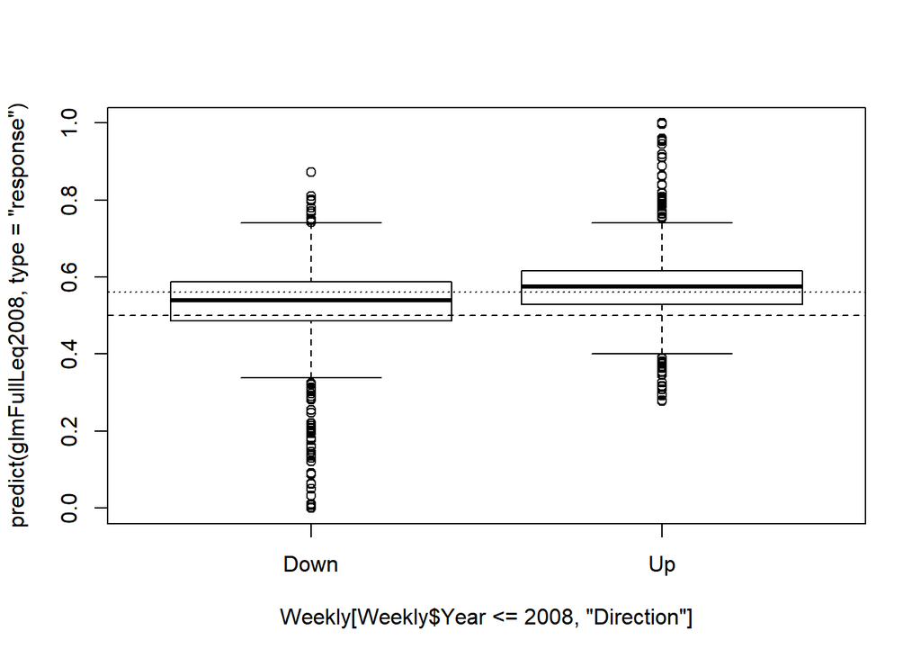

```r
boxplot(predict(glmFullLeq2008,type="response")~Weekly[Weekly$Year<=2008,"Direction"])
abline(h=0.5,lty=2)
abline(h=median(predict(glmFullLeq2008,type="response")),lty=3)
```

```r
tblTmp <- table(Weekly[Weekly$Year>2008,"Direction"],c("Down","Up")[1+(predict(glmFullLeq2008,newdata=Weekly[Weekly$Year>2008,],type="response")>median(predict(glmFullLeq2008,type="response")))])
tblTmp
```

```
##
##        Down Up
##   Down   26 17
##   Up     27 34
```

```r
tblTmp[2,2] / sum(tblTmp[2,])
```

```
## [1] 0.557377
```

```r
tblTmp[1,1] / sum(tblTmp[1,])
```

```
## [1] 0.6046512
```

```r
assess.prediction(as.numeric(Weekly[Weekly$Year>2008,"Direction"])-1,as.numeric(predict(glmFullLeq2008,newdata=Weekly[Weekly$Year>2008,],type="response")>median(predict(glmFullLeq2008,type="response"))))
```

```
## Total cases that are not NA: 104
## Correct predictions (accuracy): 60(57.7%)
## TP, TN, FP, FN, P, N: 34 26 17 27 61 43
## TPR (sensitivity)=TP/P: 55.7%
## TNR (specificity)=TN/N: 60.5%
## PPV (precision)=TP/(TP+FP): 66.7%
## FDR (false discovery)=1-PPV: 33.3%
## FPR =FP/N=1-TNR: 39.5%
```